# Hypothesis tests in regression

Qiao Su

10/21/2019

This is a fill-in-the-blank activity. Read the text, run the code, and follow the instructions, writing your answers where blanks are provided. You’ll then turn this in as a short “homework” for credit.

We’ve seen a lot about hypothesis tests in regression: *t* tests, *F* tests, and other tests. What exactly do they mean, and what do they measure?

We’ll explore this using some simulations. In each simulation, we’ll make *X* using random uniform variables that are not correlated with each other?

```r
# Generate random X with N rows and p columns.
generate_X <- function(N, p) {
  X <- matrix(runif(N * p), nrow=N)

  return(as.data.frame(X))
}
```

Here are functions to generate Y from X using beta:

```r
c
```

```
## function (...)  .Primitive("c")
```

```r
generate_error <- function(X, sigma) {
  return(sigma * rnorm(nrow(X)))
}

# Generate Y using X, beta, and the error.
generate_Y <- function(X, beta, sigma) {
  return(as.matrix(X) %*% beta + generate_error(X, sigma))
}
```

These functions will make it easy for us to extract the F statistic and $R^2$ for a model:

```r
# Return the p value for the F test of a linear model.
f_p_value <- function(fit) {
  fstat <- summary(fit)$fstatistic

  pf(fstat["value"], fstat["numdf"], fstat["dendf"], lower.tail=FALSE)
}

# Return the R^2 for a linear model fit.
r_squared <- function(fit) {
  summary(fit)$r.squared
}
```

## Power of tests

Let’s imagine running an ordinary linear model with real effects. What sample size do we need to detect those effects?

The probability of detecting a certain-size effect with a certain sample size is called the *power*. If the power is low, then our failure to detect a statistically significant difference doesn’t mean much – if a true effect were there, we quite likely wouldn’t have found it.

Try running the simulation below. Examine the plot produced and make sure you understand what the code is doing.

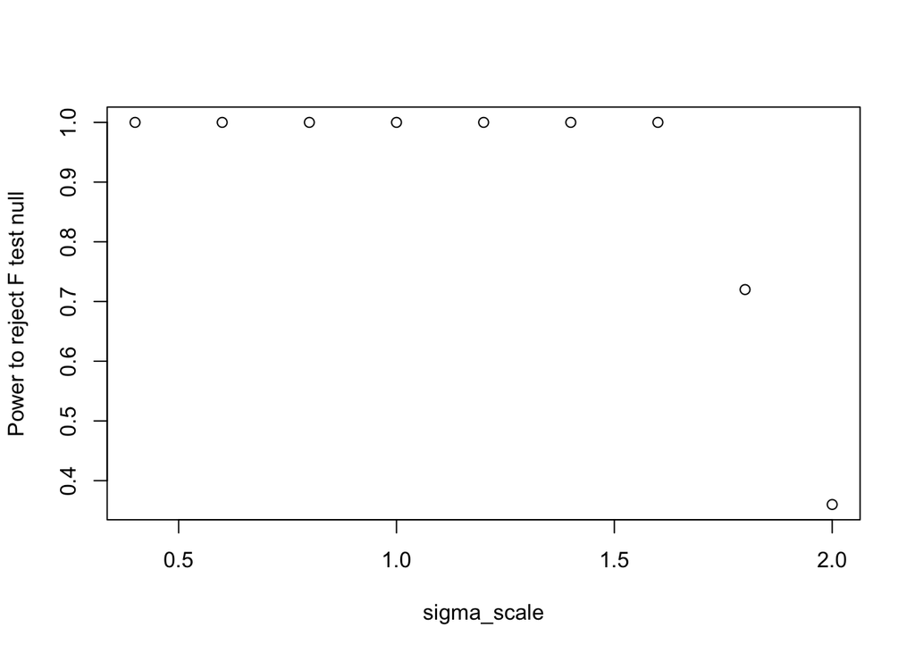

```r
beta <- c(-0.2, 0, -0.8)
sigma <- 0.5 # scale teh normal distribution

# What sample sizes should we try?
#sample_sizes <- 10:100
beta_scale <- seq(0.4, 2, by=0.2)
sigma_scale <- seq(0.4, 2, by=0.2)

# For each sample size, what fraction of the tests were significant?
num_significant <- numeric(length(beta_scale))

# How many times should we try at each sample size?
num_trials <- 100
N <- 50

for (jj in seq_along(sigma_scale)) {
 # beta <- beta*beta_scale[jj]/1.0
  sigma <- sigma*sigma_scale[jj]

  for (ii in 1:num_trials) {
    X <- generate_X(N, length(beta))
    Y <- generate_Y(X, beta, sigma)

    fit <- lm(Y ~ ., data=X) # . means "all columns"

    if (f_p_value(fit) <= 0.05) {
      num_significant[jj] <- num_significant[jj] + 1
    }
  }
}

plot(sigma_scale, num_significant / num_trials,
     xlab="sigma_scale", ylab="Power to reject F test null")
```

### Questions for you

Now, answer these questions *before* trying out more simulations. Write your answers below.

1. If the coefficients in beta are larger (in absolute value), but we keep N the same, should the power increase or decrease? Why does this make sense?
2. If sigma is larger, keeping N the same, should the power increase or decrease?
3. If we fail to reject the F test, what is a reasonable conclusion to draw? Write out a sentence of the form “Since p > 0.05, we… and conclude that…”

Answers:

1. The power should increase because we would need to show that the effect is still distinguishable from zero.
2. The power decreases since the signal is noisier.
3. Since p > 0.05, we cannot reject the null hypothesis and conclude that the coefficient beta is not significantly different from zero with a probability of 95%. We cannot distinguish whether the coefficients have an effect. However we can say that the effect size is not easy to detect.

Now try running a few more simulations (just tweak the code above) to answer questions 1 and 2. Summarize your results:

1. The power increases with increasing beta in a nonlinear way.
2. The power decreases with increasing sigma in a nonlinear way. It drops off sharply after sigma scaling factor increases past about 1.5 fold.

## The effect of doing model selection

Let’s consider doing a similar simulation. But this time, beta will be a zero vector: there is **no** effect. We run stepwise variable selection and then consider the *F* test of the selected model.

Crucially, we’ll add more variables – variables that still have no true effect.

**Before** you run the simulation below:

Question: If we add more variables, meaning more columns in *X*, but none of them are correlated with *Y*, what will happen to the *F* test after stepwise selection? Will it conclude that there are significant effects?

Answer: It will conclude that there are significant effects, because we are able to pick variables which have small p-values. As the number of variables increases the number of significant effects will increase linearly.

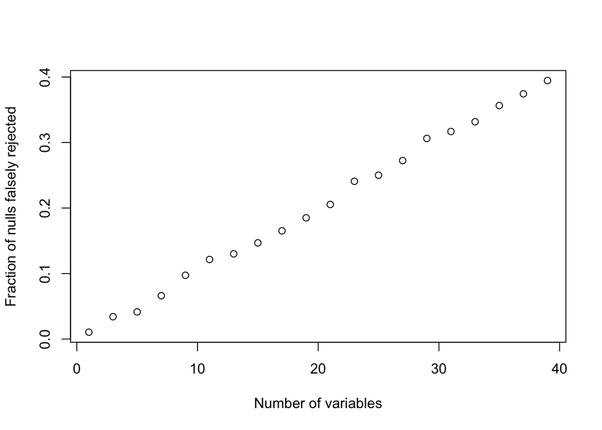

```r
sigma <- 0.5

# Sample size to try -- needs to be bigger than the number of variables
N <- 100

# How many variables to use in our model
num_variables <- seq(1, 40, by=2)

# For each number of variables, what fraction of the tests were significant?
num_significant <- numeric(length(num_variables))

# How many times should we try?
num_trials <- 50

# what is r squared?
rsq <- numeric(length(num_variables))

for (jj in seq_along(num_variables)) {
  p <- num_variables[jj]

  for (ii in 1:num_trials) {
    X <- generate_X(N, p)

    # Don't bother using generate_Y, because beta is 0. It would just do a matrix
    # multiplication with 0 for no purpose.
    Y <- generate_error(X, sigma)

    fit <- lm(Y ~ ., data=X)
    # stepwise regression
    #step_fit <- step(fit, trace=0) # do stepwise regression

    # calculate r squared
    rsq[jj] <- rsq[jj]+ summary(fit)$r.squared

    #if (length(coef(step_fit)) > 1 && f_p_value(step_fit) <= 0.05) {
    # if (length(coef(fit)) > 1 && f_p_value(fit) <= 0.05) {
    #   num_significant[jj] <- num_significant[jj] + 1
    # }
  }
}

rsq <- rsq/num_trials # take the average of all the r squareds
plot(num_variables,rsq,  #num_significant / num_trials,
     xlab="Number of variables", ylab="Fraction of nulls falsely rejected")
```

### Questions for you

Now, some questions. Answer these **before** running any more simulations:

1. What will happen if we *don’t* do stepwise selection, and just fit the model to all the variables? Will we see the same relationship in the graph?
2. The $R^2$ statistic summarizes the amount of variance in *Y* that is explained by the columns in *X*. In this simulation, none of the variation in *Y* is truly related to *X*, but some variation will be related by chance. How will $R^2$ vary with the number of variables in the model?

Answers: 1. We will not, because where stepwise selection would pick out the best variables for every number of variables, in this case there’s a random chance that any of the variables at each step would be found as a significant explanatory variable. 2. It does seem to increase because more variables are able to explain more of the varation just by chance.

Now adjust the simulations above and write what you find:

## Non-normal errors

Next question: What is the effect of non-Normal residuals on regression, and specifically on the hypothesis tests we do? We know the F test assumes normality of residuals, but how much does that matter?

We can make our errors be heavy-tailed by using a *t* distribution:

```r
# Generate errors for all X. The errors are t-distributed with 2 degrees of freedom.
generate_error_t <- function(X, sigma) {
  return(sigma * rt(nrow(X), df=2)) # rt generates random deviates.
}
```

What does this look like in a QQ plot? Run this a few times to see some examples. Ans: there are outlier residuals at the two ends of the qq plot.

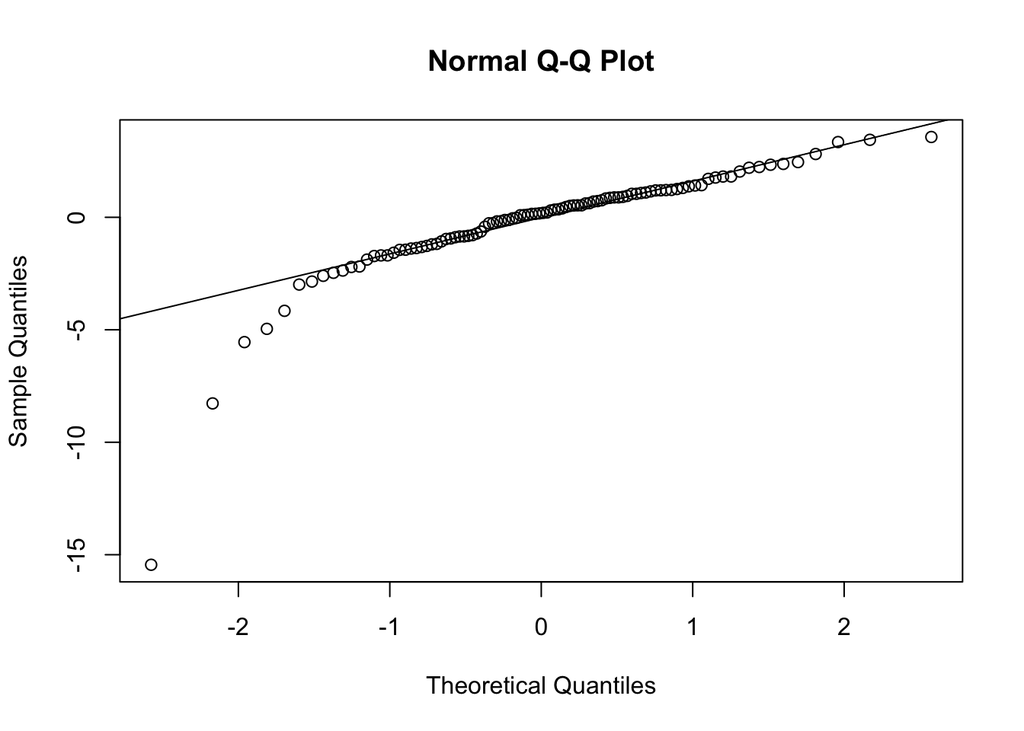

```r
data <- rt(100, df=2)
qqnorm(data)
qqline(data)
```

**Conduct simulations with p = 3 and N ranging from the smallest possible value to larger values, say N = 500. Look at the distribution of F test pvalues in each situation, both with t-distributed errors and with normally-distributed errors.**

First we chose to fit models for sample sizes at N=5 and N=300, and plot the distribution of pvalues in each case.

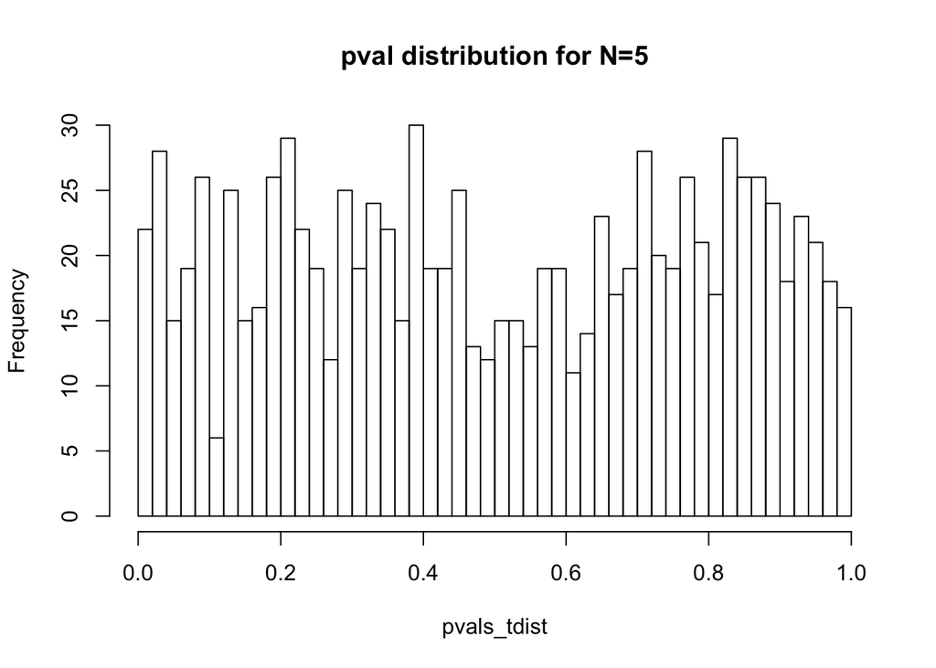

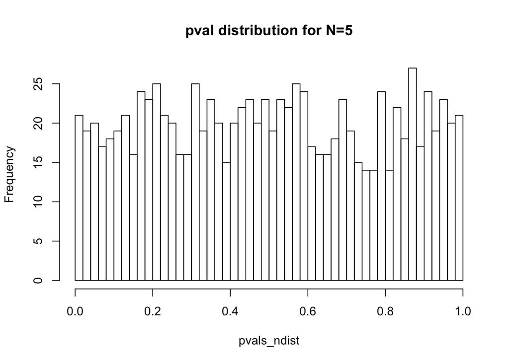

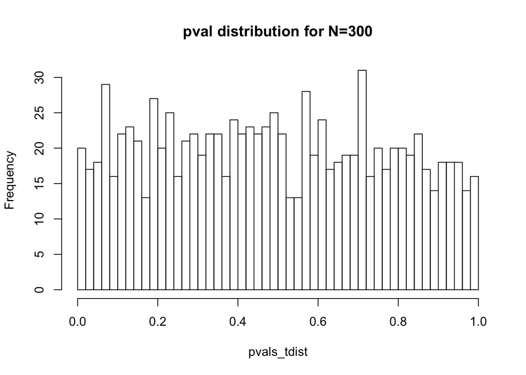

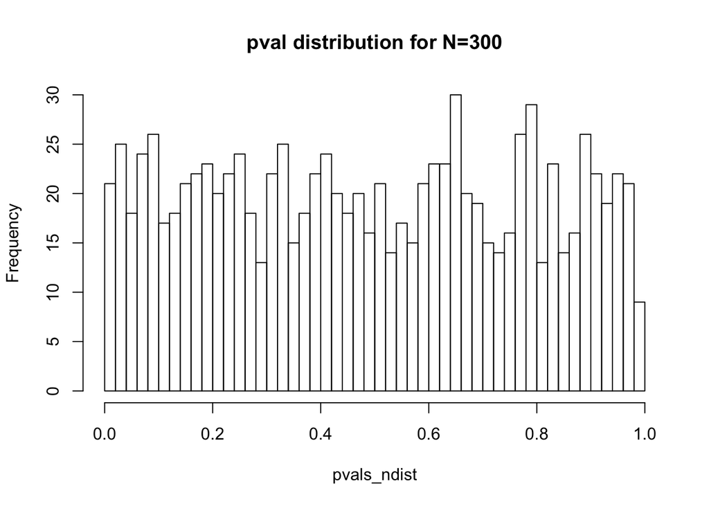

```r
sigma <- 0.5

# How many variables to use in our model
p <- 3
N <- c(5, 300) # try a large N and small N

# How many times should we try?
num_trials <- 1000

for (jj in N) {
  X <- generate_X(jj, p)
  pvals_tdist <- numeric(length(num_trials))
  pvals_ndist <- numeric(length(num_trials))
  for (ii in 1:num_trials) {
    # https://stats.stackexchange.com/questions/117626/how-can-i-work-out-the-standard-deviation-of-a-t-distribution
    Y_tdist <- generate_error_t(X, sigma)*(jj-3)/(jj-1)
    #Y_tdist <- Y_tdist/max(Y_tdist) #scale t distribution so it has the same standard deviation
    Y_ndist <- generate_error(X, sigma)
    fit_t <- lm(Y_tdist ~ ., data=X)
    fit_n <- lm(Y_ndist ~ ., data=X)

    pvals_tdist[ii] <- f_p_value(fit_t)
    pvals_ndist[ii] <- f_p_value(fit_n)
  }
  # now make a plot of the pvals.
  hist(pvals_tdist, breaks=50,
       main = paste0("pval distribution for N=", jj))
  hist(pvals_ndist, breaks=50,
       main = paste0("pval distribution for N=", jj))
 # title(main = paste0("pval distribution for N=", jj))
}
```

Next we plotted the number of F test p-values which were tested to be significant for both t and normal distribution, across a range of sample sizes, in red and black respectively.

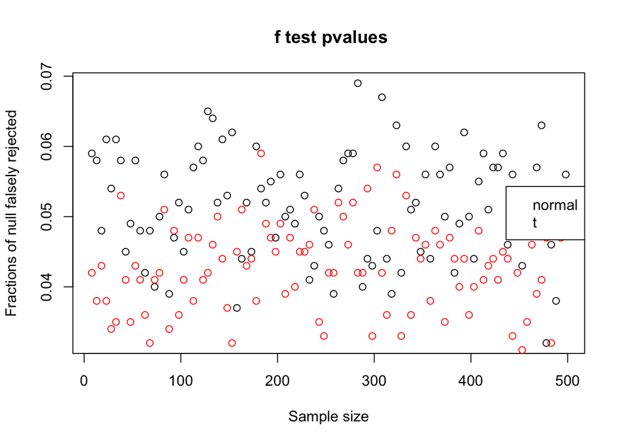

```r
sigma <- 0.5

# How many variables to use in our model
p <- 3
N <- seq(p, 500, by=5) # Sample size

# For each number of variables, what fraction of the tests were significant?
p_ndist <- numeric(length(N))
p_tdist <- numeric(length(N))

num_trials <- 1000

for (jj in 1:length(N)) {
  n <- N[jj]
  # get the average F-test p-value for a dataset with this n
  plist_n <- numeric(length(num_trials))
  plist_t <- numeric(length(num_trials))
  for (ii in 1:num_trials) {
    X <- generate_X(n, p)

    Y_tdist <- generate_error_t(X, sigma)*(n-3)/(n-1)
    Y_ndist <- generate_error(X, sigma)

    fit_t <- lm(Y_tdist ~ ., data=X)
    fit_n <- lm(Y_ndist ~ ., data=X)

    plist_n[ii] <- f_p_value(fit_n)
    plist_t[ii] <- f_p_value(fit_t)
  }

  p_ndist[jj] <- length(plist_n[plist_n < 0.05])
  p_tdist[jj]<- length(plist_t[plist_t < 0.05])
}

# Do you observe any differences in the behavior of the hypothesis test?
     #xlab="N", ylab="Density")

# What do the effects of non-normality appear to be on the F test?
plot(N[2:100],p_ndist[2:100]/num_trials,
     xlab="Sample size", ylab="Fractions of null falsely rejected",
     main = " f test pvalues")
points(N[2:100], p_tdist[2:100]/num_trials, col = "red")
legend("right",c("normal", "t"), col = par("black", "red"))
```

```r
#
#      xlab="Sample size", ylab="Average f-test pvalue",
#      main ="t-distribution f test pvalues"
# legend = c("bottomleft", legend= c("tdist", "ndist"))
```

1. Do you observe any differences in the behavior of the hypothesis tests?

2. What do the effects of non-normality appear to be on the F test?

Looking at the plot, it appears the effects might be really subtle and the t-distribution and normal distribution are very similar. However, throughout different sample sizes, the t-distribution seems to have a slightly lower fraction of falsely rejected F-test null results. This could lead to slight inflation of F-test pvalues.